# plotLoadings - what it plots?

A. Blejec

2024-11-19

## Package

```r
library(mixOmics)
```

## Get saved model

Model for H-HD

```r
source("final-diablo-model-H-HD.R")
```

## plotLoadings

The function “plotLoadings” visualises the loading weights of each selected variable on each component and each data set. The colour indicates the class in which the variable has the maximum level of expression “contrib = ‘max’” using the median “method = ‘median’”. Figure below depicts the loading values for each dimension.

Loadings have the same meaning as in PCA:

For each case,

component score = sum (loadings * variable)

$$score_{k,i}=\sum_j{} l_{j,k} *
x_{i,j}$$

```r
loadings <- final.diablo.model$loadings
head(loadings)
```

```
## $proteomics
##                              comp1        comp2      comp3       comp4
## VdnDe2_86784            0.00000000  0.000000000  0.0000000 -0.06735096
## PBdnRY1_7025           -0.44143276  0.000000000  0.0000000  0.00000000
## VdnPW5_1541             0.00000000  0.000000000  0.0000000  0.44326596
## CLCdnPW10_11437        -0.02332251  0.000000000  0.0000000 -0.54464157
## CLCdnDe2_96512          0.00000000  0.000000000  0.0000000  0.00000000
## VdnPW1_81435            0.00000000  0.000000000  0.0000000  0.00000000
## CLCdnDe6_4953          -0.42082687  0.000000000  0.0000000  0.00000000
## CLCdnDe13_5738          0.00000000  0.000000000  0.0000000  0.00000000
## CLCdnPW12_1472          0.00000000  0.350293122  0.0000000  0.01575126
## CLCdnPW49_8560          0.34021934  0.000000000 -0.1704210  0.00000000
## VdnPW4_18801            0.00000000  0.000000000 -0.1144868 -0.46776619
## SdnRY1_10712            0.00000000  0.000000000 -0.6019851  0.00000000
## CLCdnDe2_311            0.00000000  0.000000000  0.0000000  0.00000000
## CLCdnDe13_63179         0.00000000  0.000000000 -0.0708519  0.00000000
## CLCdnDe10_24187         0.00000000  0.000000000  0.0000000 -0.05914870
## TDe_comp110944_c2_seq4  0.00000000  0.000000000  0.0000000  0.00000000
## PBdnRY1_11085           0.00000000  0.000000000  0.0000000  0.00000000
## CLCdnPW48_15164         0.00000000  0.480062127  0.0000000  0.00000000
## CLCdnPW31_956           0.00000000 -0.065156379 -0.1390019  0.00000000
## VdnDe1_162036           0.00000000  0.000000000  0.0000000  0.00000000
## PBdnRY1_2239            0.47136497  0.000000000  0.0000000  0.00000000
## CLCdnPW22_15452         0.00000000  0.005097524  0.0000000  0.15284273
## CLCdnPW50_2470          0.00000000  0.000000000  0.0000000  0.00000000
## VdnPW3_37011            0.27345111  0.000000000  0.0000000  0.00000000
## SdnPW1_46               0.08771088  0.000000000  0.1707496  0.00000000
## CLCdnDe7_34340          0.00000000  0.000000000  0.0000000  0.00000000
## CLCdnDe11_2286          0.00000000  0.000000000  0.0000000  0.00000000
## VdnDe2_53978            0.00000000  0.736428175  0.0000000  0.00000000
## CLCdnDe7_6144           0.00000000  0.000000000  0.6719554  0.00000000
## CLCdnRY10_6741          0.00000000 -0.088358403  0.0000000  0.00000000
## PBdnRY1_5389            0.45507701  0.000000000  0.0000000  0.00000000
## VdnDe2_29290            0.00000000  0.000000000  0.0000000  0.00000000
## VdnDe4_115100           0.00000000  0.000000000  0.0000000 -0.50639107
## Sotub11g025210.1.1      0.00000000  0.303741066  0.0000000  0.00000000
## VdnDe1_39992            0.00000000  0.000000000  0.3007365  0.00000000
## VdnPW4_15664            0.00000000  0.013093679  0.0000000  0.00000000
##                              comp5
## VdnDe2_86784           -0.69676166
```

[output cut: 97 more lines]

```
## TOP.AREA           0.2199335  0.63645931  0.04313912  0.00620657  0.2190688
## COMPACTNESS        0.2041419  0.45832204  0.53032085 -0.03241622 -0.4182404
## Fv.Fm             -0.4625215  0.30497463 -0.18273054  0.44490428 -0.1332819
## qL                -0.4120210  0.06090967  0.49717175  0.41798071  0.4868633
## deltaT             0.4199447 -0.10546911  0.40994455 -0.09286246  0.3233908
## WATER.CONSUMPTION -0.1460120  0.46930976 -0.34533037 -0.48442858  0.4046802
##
## $Y
##           comp1       comp2       comp3       comp4       comp5
## H01  -0.5214744 -0.56788837 -0.16425163  0.25241333 -0.22728468
## H07  -0.1971000 -0.01353640 -0.34966286 -0.69771960 -0.03524642
## H08  -0.2245280  0.74628566 -0.01066872 -0.02616684 -0.32339882
## H14   0.6134459  0.08191792 -0.53448854  0.29255550  0.28516756
## HD08 -0.1577789  0.08059201  0.57508246  0.50610955  0.74869675
## HD14  0.4874354 -0.32737083  0.48398929 -0.32719195 -0.44793439
```

Take proteomics loadings for component $m$

```r
m <- 1
names(final.diablo.model$loadings[m])
```

```
## [1] "proteomics"
```

```r
names(loadings)
```

```
## [1] "proteomics"   "metabolomics" "hormonomics"  "qPCR"         "phenomics"
## [6] "Y"
```

```r
loadings[m]
```

```
## $proteomics
##                              comp1        comp2      comp3       comp4
## VdnDe2_86784            0.00000000  0.000000000  0.0000000 -0.06735096
## PBdnRY1_7025           -0.44143276  0.000000000  0.0000000  0.00000000
## VdnPW5_1541             0.00000000  0.000000000  0.0000000  0.44326596
## CLCdnPW10_11437        -0.02332251  0.000000000  0.0000000 -0.54464157
## CLCdnDe2_96512          0.00000000  0.000000000  0.0000000  0.00000000
## VdnPW1_81435            0.00000000  0.000000000  0.0000000  0.00000000
## CLCdnDe6_4953          -0.42082687  0.000000000  0.0000000  0.00000000
## CLCdnDe13_5738          0.00000000  0.000000000  0.0000000  0.00000000
## CLCdnPW12_1472          0.00000000  0.350293122  0.0000000  0.01575126
## CLCdnPW49_8560          0.34021934  0.000000000 -0.1704210  0.00000000
## VdnPW4_18801            0.00000000  0.000000000 -0.1144868 -0.46776619
## SdnRY1_10712            0.00000000  0.000000000 -0.6019851  0.00000000
## CLCdnDe2_311            0.00000000  0.000000000  0.0000000  0.00000000
## CLCdnDe13_63179         0.00000000  0.000000000 -0.0708519  0.00000000
## CLCdnDe10_24187         0.00000000  0.000000000  0.0000000 -0.05914870
## TDe_comp110944_c2_seq4  0.00000000  0.000000000  0.0000000  0.00000000
## PBdnRY1_11085           0.00000000  0.000000000  0.0000000  0.00000000
## CLCdnPW48_15164         0.00000000  0.480062127  0.0000000  0.00000000
## CLCdnPW31_956           0.00000000 -0.065156379 -0.1390019  0.00000000
## VdnDe1_162036           0.00000000  0.000000000  0.0000000  0.00000000
## PBdnRY1_2239            0.47136497  0.000000000  0.0000000  0.00000000
## CLCdnPW22_15452         0.00000000  0.005097524  0.0000000  0.15284273
## CLCdnPW50_2470          0.00000000  0.000000000  0.0000000  0.00000000
## VdnPW3_37011            0.27345111  0.000000000  0.0000000  0.00000000
## SdnPW1_46               0.08771088  0.000000000  0.1707496  0.00000000
## CLCdnDe7_34340          0.00000000  0.000000000  0.0000000  0.00000000
## CLCdnDe11_2286          0.00000000  0.000000000  0.0000000  0.00000000
## VdnDe2_53978            0.00000000  0.736428175  0.0000000  0.00000000
## CLCdnDe7_6144           0.00000000  0.000000000  0.6719554  0.00000000
## CLCdnRY10_6741          0.00000000 -0.088358403  0.0000000  0.00000000
## PBdnRY1_5389            0.45507701  0.000000000  0.0000000  0.00000000
## VdnDe2_29290            0.00000000  0.000000000  0.0000000  0.00000000
## VdnDe4_115100           0.00000000  0.000000000  0.0000000 -0.50639107
## Sotub11g025210.1.1      0.00000000  0.303741066  0.0000000  0.00000000
## VdnDe1_39992            0.00000000  0.000000000  0.3007365  0.00000000
## VdnPW4_15664            0.00000000  0.013093679  0.0000000  0.00000000
##                              comp5
## VdnDe2_86784           -0.69676166
```

[output cut: 20 more lines]

```
## CLCdnPW22_15452         0.03340180
## CLCdnPW50_2470          0.00000000
## VdnPW3_37011            0.00000000
## SdnPW1_46               0.00000000
## CLCdnDe7_34340          0.00000000
## CLCdnDe11_2286          0.00000000
## VdnDe2_53978            0.00000000
## CLCdnDe7_6144           0.00000000
## CLCdnRY10_6741          0.00000000
## PBdnRY1_5389            0.00000000
## VdnDe2_29290            0.00000000
## VdnDe4_115100           0.00000000
## Sotub11g025210.1.1      0.24006294
## VdnDe1_39992            0.00000000
## VdnPW4_15664            0.00000000
```

```r
loadings <- loadings[[m]][,1]
loadings
```

```
##           VdnDe2_86784           PBdnRY1_7025            VdnPW5_1541
##             0.00000000            -0.44143276             0.00000000
##        CLCdnPW10_11437         CLCdnDe2_96512           VdnPW1_81435
##            -0.02332251             0.00000000             0.00000000
##          CLCdnDe6_4953         CLCdnDe13_5738         CLCdnPW12_1472
##            -0.42082687             0.00000000             0.00000000
##         CLCdnPW49_8560           VdnPW4_18801           SdnRY1_10712
##             0.34021934             0.00000000             0.00000000
##           CLCdnDe2_311        CLCdnDe13_63179        CLCdnDe10_24187
##             0.00000000             0.00000000             0.00000000
## TDe_comp110944_c2_seq4          PBdnRY1_11085        CLCdnPW48_15164
##             0.00000000             0.00000000             0.00000000
##          CLCdnPW31_956          VdnDe1_162036           PBdnRY1_2239
##             0.00000000             0.00000000             0.47136497
##        CLCdnPW22_15452         CLCdnPW50_2470           VdnPW3_37011
##             0.00000000             0.00000000             0.27345111
##              SdnPW1_46         CLCdnDe7_34340         CLCdnDe11_2286
##             0.08771088             0.00000000             0.00000000
##           VdnDe2_53978          CLCdnDe7_6144         CLCdnRY10_6741
##             0.00000000             0.00000000             0.00000000
##           PBdnRY1_5389           VdnDe2_29290          VdnDe4_115100
##             0.45507701             0.00000000             0.00000000
##     Sotub11g025210.1.1           VdnDe1_39992           VdnPW4_15664
##             0.00000000             0.00000000             0.00000000
```

Take nonzero loadings and order by absolute value

```r
loadings <- loadings[loadings!=0]
loadings <- loadings[order(abs(loadings))]
as.data.frame(loadings)
```

```
##                    loadings
## CLCdnPW10_11437 -0.02332251
## SdnPW1_46        0.08771088
## VdnPW3_37011     0.27345111
## CLCdnPW49_8560   0.34021934
## CLCdnDe6_4953   -0.42082687
## PBdnRY1_7025    -0.44143276
## PBdnRY1_5389     0.45507701
## PBdnRY1_2239     0.47136497
```

This is plotted by plotLoadings

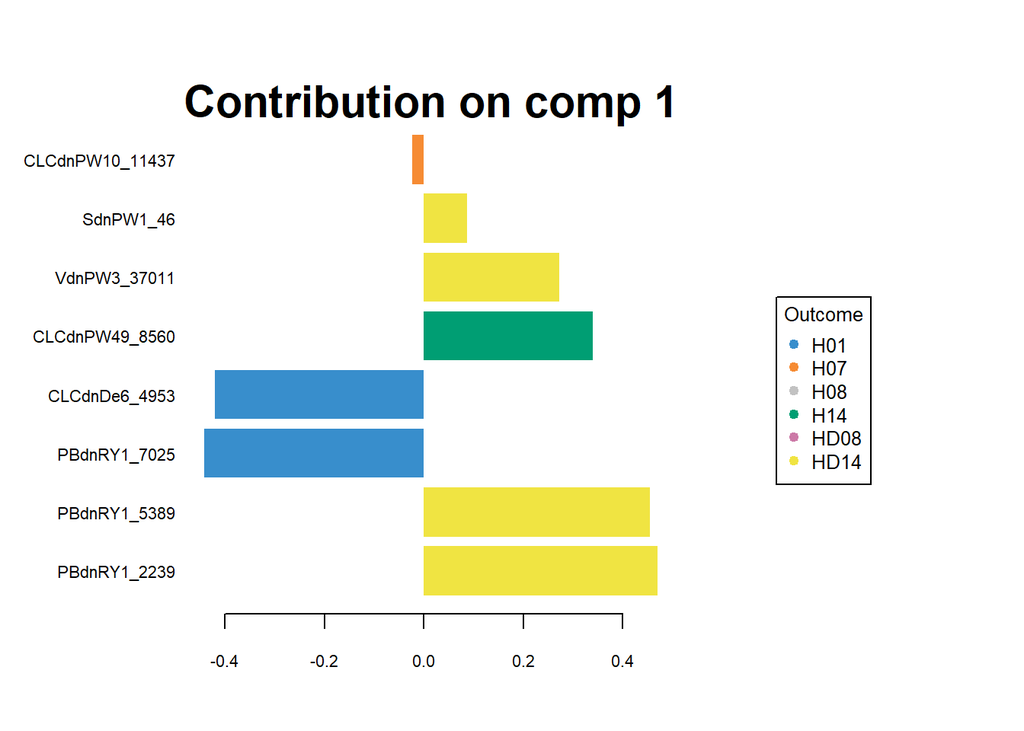

```r
plotLoadings(final.diablo.model,block = m,comp=1,contrib = "max",     method = "median")
```

Colors show groups with maximal median measurements for each variable.

Variable with maximal absolute loading is:

```r
maxl <- which(abs(loadings)==max(abs(loadings)))
loadings[maxl]
```

```
## PBdnRY1_2239
##     0.471365
```

Get data:

```r
names(final.diablo.model$X)
```

```
## [1] "proteomics"   "metabolomics" "hormonomics"  "qPCR"         "phenomics"
```

```r
x <- final.diablo.model$X[[m]]
head(x)
```

```
##        VdnDe2_86784 PBdnRY1_7025 VdnPW5_1541 CLCdnPW10_11437 CLCdnDe2_96512
## H_S1_1   0.05599433    1.0413597 -0.08306042       0.8229892             NA
## H_S1_2   2.05791313    0.7756008  2.01107963      -0.1073243             NA
## H_S1_3   0.87785105    2.0111652  1.85826969      -0.1859922             NA
## H_S1_4   1.60364141    1.4424158  0.42747028       0.4128072             NA
## H_S7_1   0.82754364    0.4900269 -0.71322077       1.8241753             NA
## H_S7_2   0.42066066   -0.9518129 -1.21966157       2.2229418             NA
##        VdnPW1_81435 CLCdnDe6_4953 CLCdnDe13_5738 CLCdnPW12_1472 CLCdnPW49_8560
## H_S1_1    0.1773199     2.0359825             NA     -0.8562156     -1.0243551
## H_S1_2   -0.6066207     1.1082184             NA     -1.1328254     -1.0739640
## H_S1_3   -0.9052647     0.7088562             NA     -1.3995379             NA
## H_S1_4    1.3345654     1.3977371             NA     -0.8365991             NA
## H_S7_1           NA     1.6052343       1.106514     -1.2772564     -0.2306123
## H_S7_2           NA    -0.3661409      -1.237903     -1.0840223     -0.1012747
##        VdnPW4_18801 SdnRY1_10712 CLCdnDe2_311 CLCdnDe13_63179 CLCdnDe10_24187
## H_S1_1   -0.7034161   0.76440697   1.25695036      -1.1441866              NA
## H_S1_2   -1.8455653   0.93797539  -1.16245141      -1.2367426              NA
## H_S1_3   -1.4987440   0.81824533  -0.54573710      -1.8523798              NA
## H_S1_4   -0.8175398   0.64564964   0.07750556       1.1371352              NA
## H_S7_1    1.0381210  -0.02559577  -0.05509413       0.3096009     -0.10858088
## H_S7_2    0.9700087   0.24414579   1.96151326       2.0362320      0.06839796
##        TDe_comp110944_c2_seq4 PBdnRY1_11085 CLCdnPW48_15164 CLCdnPW31_956
## H_S1_1             -1.1956211            NA      -1.5128812   -0.83765464
## H_S1_2             -1.2581506            NA      -0.1222120    0.02897020
## H_S1_3                     NA            NA       0.7975189   -0.06111908
## H_S1_4             -1.1009819            NA      -1.7840318    1.03248859
## H_S7_1              0.7125254            NA       1.2279650    0.47876791
## H_S7_2              0.9525372            NA       0.4054191   -0.06765481
##        VdnDe1_162036 PBdnRY1_2239 CLCdnPW22_15452 CLCdnPW50_2470 VdnPW3_37011
## H_S1_1     1.1774840   -0.4656256      0.40260689             NA   -0.1372252
## H_S1_2     0.9091004   -0.8038269      0.17752270             NA   -1.4770277
## H_S1_3    -0.3163266   -1.0698223      0.09141801             NA   -2.2555413
## H_S1_4    -1.1844272   -0.3234118     -0.99709683             NA   -0.7321458
## H_S7_1    -1.2396244   -1.2209277     -1.06602653             NA   -0.3880623
## H_S7_2     0.3188923   -0.5640564     -0.92242299             NA   -0.6345397
##          SdnPW1_46 CLCdnDe7_34340 CLCdnDe11_2286 VdnDe2_53978 CLCdnDe7_6144
## H_S1_1 -0.96892090             NA             NA   -1.1159937    1.00776471
## H_S1_2 -1.39730999             NA             NA   -0.5584242    0.01732626
## H_S1_3 -1.40779046             NA             NA   -1.6353297    1.41991335
## H_S1_4 -1.32525678             NA             NA   -0.5023151   -0.44619097
## H_S7_1 -0.07015534             NA     -0.2956270    0.9833693   -0.51800338
## H_S7_2 -0.61520513             NA     -0.2492624    0.8952335   -1.31049412
##        CLCdnRY10_6741 PBdnRY1_5389 VdnDe2_29290 VdnDe4_115100
## H_S1_1             NA  -1.02747021    0.2436520     -1.181434
## H_S1_2      0.9369095  -1.66280989   -1.3234857     -1.132019
## H_S1_3      2.5365111  -1.52592143   -1.1349096     -1.600164
## H_S1_4             NA  -1.23721597   -0.8287211     -1.329505
## H_S7_1     -0.5597687  -0.01358011   -0.1070481      1.102966
## H_S7_2     -0.3871837  -0.08616699   -0.1880716      1.392833
##        Sotub11g025210.1.1 VdnDe1_39992 VdnPW4_15664
## H_S1_1         -1.0790430   1.44779004           NA
## H_S1_2         -0.4973246   0.05988999           NA
## H_S1_3         -1.7631057   0.48134149           NA
## H_S1_4         -1.2297375   0.67619353           NA
## H_S7_1         -0.8863173  -0.69026537           NA
## H_S7_2          0.3826289   0.18000013           NA
```

And select variable for selected loading

```r
x[,names(maxl),drop=FALSE]
```

```
##          PBdnRY1_2239
## H_S1_1    -0.46562565
## H_S1_2    -0.80382691
## H_S1_3    -1.06982229
## H_S1_4    -0.32341178
## H_S7_1    -1.22092765
## H_S7_2    -0.56405642
## H_S7_3    -0.44969090
## H_S7_4    -0.01012416
## H_S8_1    -0.09821484
## H_S8_2    -0.05238371
## H_S8_3    -0.33140413
## H_S8_4    -0.17625264
## H_S14_1    0.77060350
## H_S14_2    0.25785682
## H_S14_3    0.24476935
## H_S14_4    1.52982676
## HD_S8_1   -0.85128149
## HD_S8_2   -1.29710473
## HD_S8_3   -0.58153969
## HD_S8_4   -0.89124323
## HD_S14_1   0.45127168
## HD_S14_2   2.33124712
## HD_S14_3   1.80683660
## HD_S14_4   1.79449841
```

```r
x <- x[,names(maxl),drop=FALSE]
```

plotLoadings is using maximal median vale by groups.

Medians of values by group

```r
group <- final.diablo.model$Y
med <- aggregate((x),list(group),median)
med
```

```
##   Group.1 PBdnRY1_2239
## 1     H01   -0.6347263
## 2     H07   -0.5068737
## 3     H08   -0.1372337
## 4     H14    0.5142302
## 5    HD08   -0.8712624
## 6    HD14    1.8006675
```

```r
maxm <- which(med[,2]==max(med[,2]))
maxmed <- med[maxm,]
maxmed
```

```
##   Group.1 PBdnRY1_2239
## 6    HD14     1.800668
```

We can see that the group with maximal median measurement is in group

```r
as.character(maxmed[,1])
```

```
## [1] "HD14"
```

which is indicated by the color on the plot

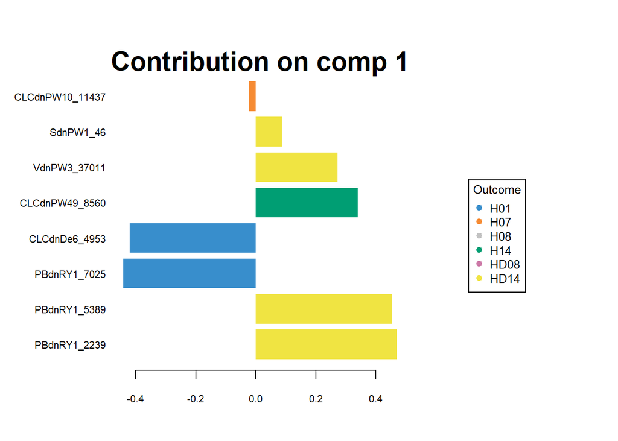

```r
plotLoadings(final.diablo.model,block = m,comp=1,contrib = "max",     method = "median")
```

## Note for cases with possible negative measurements.

IN such case, more sense would be the maximal median of absolute values, since the product of such value with loading gives higher contribution. This dilemma exists only with negative measured values.

Contribution

```r
med
```

```
##   Group.1 PBdnRY1_2239
## 1     H01   -0.6347263
## 2     H07   -0.5068737
## 3     H08   -0.1372337
## 4     H14    0.5142302
## 5    HD08   -0.8712624
## 6    HD14    1.8006675
```

```r
loadings[maxl]
```

```
## PBdnRY1_2239
##     0.471365
```

```r
contr <- med[,2]*loadings[maxl]
names(contr) <- med[,1]
contr
```

```
##         H01         H07         H08         H14        HD08        HD14
## -0.29918773 -0.23892249 -0.06468718  0.24239008 -0.41068255  0.84877158
```

### Using median of absolute values

```r
group <- final.diablo.model$Y
med <- aggregate((x),list(group),median)
med
```

```
##   Group.1 PBdnRY1_2239
## 1     H01   -0.6347263
## 2     H07   -0.5068737
## 3     H08   -0.1372337
## 4     H14    0.5142302
## 5    HD08   -0.8712624
## 6    HD14    1.8006675
```

```r
amed <- aggregate(abs(x),list(group),median)
amed
```

```
##   Group.1 PBdnRY1_2239
## 1     H01    0.6347263
## 2     H07    0.5068737
## 3     H08    0.1372337
## 4     H14    0.5142302
## 5    HD08    0.8712624
## 6    HD14    1.8006675
```

```r
maxm <- which(amed[,2]==max(amed[,2]))
maxamed <- med[maxm,]
maxamed
```

```
##   Group.1 PBdnRY1_2239
## 6    HD14     1.800668
```

We can see that the group with maximal median measurement is in group

```r
as.character(maxamed[,1])
```

```
## [1] "HD14"
```

Contribution

```r
med
```

```
##   Group.1 PBdnRY1_2239
## 1     H01   -0.6347263
## 2     H07   -0.5068737
## 3     H08   -0.1372337
## 4     H14    0.5142302
## 5    HD08   -0.8712624
## 6    HD14    1.8006675
```

```r
loadings[maxl]
```

```
## PBdnRY1_2239
##     0.471365
```

```r
contr <- med[,2]*loadings[maxl]
names(contr) <- med[,1]
contr
```

```
##         H01         H07         H08         H14        HD08        HD14
## -0.29918773 -0.23892249 -0.06468718  0.24239008 -0.41068255  0.84877158
```

We can see that the group with maximal median measurement is in group

```r
as.character(maxamed[,1])
```

```
## [1] "HD14"
```